```python
%matplotlib inline

import warnings
warnings.filterwarnings("ignore")
warnings.simplefilter('ignore')
import numpy as np
import pandas as pd
import matplotlib.pyplot as plt
import seaborn as sns
from sklearn.model_selection import train_test_split
from sklearn.linear_model import LogisticRegression
from sklearn.neighbors import KNeighborsClassifier
from sklearn.ensemble import RandomForestClassifier
from sklearn.ensemble import GradientBoostingClassifier
from sklearn.ensemble import AdaBoostClassifier
from sklearn.tree import DecisionTreeClassifier
from sklearn import metrics
from sklearn.metrics import roc_auc_score, roc_curve
from sklearn.linear_model import LogisticRegression
from sklearn.neighbors import KNeighborsClassifier
from sklearn.svm import SVC
from sklearn.ensemble import RandomForestClassifier
from sklearn.naive_bayes import GaussianNB
from xgboost import XGBClassifier
from sklearn import model_selection
from sklearn.utils import class_weight
from sklearn.metrics import classification_report
from sklearn.metrics import confusion_matrix
from sklearn.preprocessing import LabelEncoder
from scipy import stats
from sklearn.preprocessing import MinMaxScaler
from scipy.stats import zscore
from sklearn.metrics import accuracy_score, confusion_matrix
from sklearn.naive_bayes import GaussianNB
from sklearn.metrics import  recall_score, roc_auc_score, precision_score
from sklearn import model_selection
```

```python
import imblearn
from imblearn import under_sampling, over_sampling
from imblearn.over_sampling import SMOTE
```

# Importing dataset and null value treatment

```python
df=pd.read_csv('signal-data.csv')
```

```python
df
```

|  | Time | 0 | 1 | 2 | 3 | 4 | 5 | 6 | 7 | 8 | ... | 581 | 582 | 583 | 584 | 585 | 586 | 587 | 588 | 589 | Pass/Fail |
| --- | --- | --- | --- | --- | --- | --- | --- | --- | --- | --- | --- | --- | --- | --- | --- | --- | --- | --- | --- | --- | --- |
| 0 | 2008-07-19 11:55:00 | 3030.93 | 2564.00 | 2187.7333 | 1411.1265 | 1.3602 | 100.0 | 97.6133 | 0.1242 | 1.5005 | ... | NaN | 0.5005 | 0.0118 | 0.0035 | 2.3630 | NaN | NaN | NaN | NaN | -1 |
| 1 | 2008-07-19 12:32:00 | 3095.78 | 2465.14 | 2230.4222 | 1463.6606 | 0.8294 | 100.0 | 102.3433 | 0.1247 | 1.4966 | ... | 208.2045 | 0.5019 | 0.0223 | 0.0055 | 4.4447 | 0.0096 | 0.0201 | 0.0060 | 208.2045 | -1 |
| 2 | 2008-07-19 13:17:00 | 2932.61 | 2559.94 | 2186.4111 | 1698.0172 | 1.5102 | 100.0 | 95.4878 | 0.1241 | 1.4436 | ... | 82.8602 | 0.4958 | 0.0157 | 0.0039 | 3.1745 | 0.0584 | 0.0484 | 0.0148 | 82.8602 | 1 |
| 3 | 2008-07-19 14:43:00 | 2988.72 | 2479.90 | 2199.0333 | 909.7926 | 1.3204 | 100.0 | 104.2367 | 0.1217 | 1.4882 | ... | 73.8432 | 0.4990 | 0.0103 | 0.0025 | 2.0544 | 0.0202 | 0.0149 | 0.0044 | 73.8432 | -1 |
| 4 | 2008-07-19 15:22:00 | 3032.24 | 2502.87 | 2233.3667 | 1326.5200 | 1.5334 | 100.0 | 100.3967 | 0.1235 | 1.5031 | ... | NaN | 0.4800 | 0.4766 | 0.1045 | 99.3032 | 0.0202 | 0.0149 | 0.0044 | 73.8432 | -1 |
| ... | ... | ... | ... | ... | ... | ... | ... | ... | ... | ... | ... | ... | ... | ... | ... | ... | ... | ... | ... | ... | ... |
| 1562 | 2008-10-16 15:13:00 | 2899.41 | 2464.36 | 2179.7333 | 3085.3781 | 1.4843 | 100.0 | 82.2467 | 0.1248 | 1.3424 | ... | 203.1720 | 0.4988 | 0.0143 | 0.0039 | 2.8669 | 0.0068 | 0.0138 | 0.0047 | 203.1720 | -1 |
| 1563 | 2008-10-16 20:49:00 | 3052.31 | 2522.55 | 2198.5667 | 1124.6595 | 0.8763 | 100.0 | 98.4689 | 0.1205 | 1.4333 | ... | NaN | 0.4975 | 0.0131 | 0.0036 | 2.6238 | 0.0068 | 0.0138 | 0.0047 | 203.1720 | -1 |
| 1564 | 2008-10-17 05:26:00 | 2978.81 | 2379.78 | 2206.3000 | 1110.4967 | 0.8236 | 100.0 | 99.4122 | 0.1208 | NaN | ... | 43.5231 | 0.4987 | 0.0153 | 0.0041 | 3.0590 | 0.0197 | 0.0086 | 0.0025 | 43.5231 | -1 |
| 1565 | 2008-10-17 06:01:00 | 2894.92 | 2532.01 | 2177.0333 | 1183.7287 | 1.5726 | 100.0 | 98.7978 | 0.1213 | 1.4622 | ... | 93.4941 | 0.5004 | 0.0178 | 0.0038 | 3.5662 | 0.0262 | 0.0245 | 0.0075 | 93.4941 | -1 |
| 1566 | 2008-10-17 06:07:00 | 2944.92 | 2450.76 | 2195.4444 | 2914.1792 | 1.5978 | 100.0 | 85.1011 | 0.1235 | NaN | ... | 137.7844 | 0.4987 | 0.0181 | 0.0040 | 3.6275 | 0.0117 | 0.0162 | 0.0045 | 137.7844 | -1 |

1567 rows × 592 columns

```python
df.dtypes
```

```
Time          object
0            float64
1            float64
2            float64
3            float64
              ...
586          float64
587          float64
588          float64
589          float64
Pass/Fail      int64
Length: 592, dtype: object
```

```python
df.isnull().sum().sum()
```

```
41951
```

```python
df['Pass/Fail'].isnull().any()
```

```
False
```

```python
cl=df.columns
cl
```

```
Index(['Time', '0', '1', '2', '3', '4', '5', '6', '7', '8',
       ...
       '581', '582', '583', '584', '585', '586', '587', '588', '589',
       'Pass/Fail'],
      dtype='object', length=592)
```

# Removing columns having more than 50% null values.

```python
null_columns_list=[]
for c in cl:
    if df[c].isnull().sum()>750:
        null_columns_list.append(c)
```

```python
null_columns_list
```

```
['72',
 '73',
 '85',
 '109',
 '110',
 '111',
 '157',
 '158',
 '220',
 '244',
 '245',
 '246',
 '292',
 '293',
 '345',
 '346',
 '358',
 '382',
 '383',
 '384',
 '492',
 '516',
 '517',
 '518',
 '578',
 '579',
 '580',
 '581']
```

```python
df.drop(null_columns_list,axis=1,inplace=True)
```

```python
df.shape
```

```
(1567, 564)
```

```python
df.drop(['Time'],axis=1,inplace=True)
```

Replacing null values with zero.

```python
#df.fillna((df.median()), inplace=True)
df.fillna(0, inplace=True)
```

```python
df.columns
```

```
Index(['0', '1', '2', '3', '4', '5', '6', '7', '8', '9',
       ...
       '577', '582', '583', '584', '585', '586', '587', '588', '589',
       'Pass/Fail'],
      dtype='object', length=563)
```

```python
df['Pass/Fail'].unique()
```

```
array([-1,  1], dtype=int64)
```

```python
df.isnull().sum().sum()
```

```
0
```

```python
df.describe()
```

|  | 0 | 1 | 2 | 3 | 4 | 5 | 6 | 7 | 8 | 9 | ... | 577 | 582 | 583 | 584 | 585 | 586 | 587 | 588 | 589 | Pass/Fail |
| --- | --- | --- | --- | --- | --- | --- | --- | --- | --- | --- | --- | --- | --- | --- | --- | --- | --- | --- | --- | --- | --- |
| count | 1567.000000 | 1567.000000 | 1567.000000 | 1567.000000 | 1567.000000 | 1567.000000 | 1567.000000 | 1567.000000 | 1567.000000 | 1567.000000 | ... | 1567.000000 | 1567.000000 | 1567.000000 | 1567.000000 | 1567.000000 | 1567.000000 | 1567.000000 | 1567.000000 | 1567.000000 | 1567.000000 |
| mean | 3002.910638 | 2484.700932 | 2180.887035 | 1383.901023 | 4.159516 | 99.106573 | 100.209538 | 0.121122 | 1.460995 | -0.000840 | ... | 16.642363 | 0.499777 | 0.015308 | 0.003844 | 3.065869 | 0.021445 | 0.016464 | 0.005280 | 99.606461 | -0.867262 |
| std | 200.204648 | 184.815753 | 209.206773 | 458.937272 | 56.104457 | 9.412812 | 11.363940 | 0.012831 | 0.090461 | 0.015107 | ... | 12.485267 | 0.013084 | 0.017179 | 0.003721 | 3.577730 | 0.012366 | 0.008815 | 0.002869 | 93.895701 | 0.498010 |
| min | 0.000000 | 0.000000 | 0.000000 | 0.000000 | 0.000000 | 0.000000 | 0.000000 | 0.000000 | 0.000000 | -0.053400 | ... | 4.582000 | 0.000000 | 0.000000 | 0.000000 | 0.000000 | -0.016900 | 0.000000 | 0.000000 | 0.000000 | -1.000000 |
| 25% | 2965.670000 | 2451.515000 | 2180.700000 | 1080.116050 | 1.011000 | 100.000000 | 97.762200 | 0.121100 | 1.410950 | -0.010800 | ... | 11.501550 | 0.497900 | 0.011600 | 0.003100 | 2.306200 | 0.013400 | 0.010600 | 0.003300 | 44.368600 | -1.000000 |
| 50% | 3010.920000 | 2498.910000 | 2200.955600 | 1283.436800 | 1.310100 | 100.000000 | 101.492200 | 0.122400 | 1.461500 | -0.001300 | ... | 13.817900 | 0.500200 | 0.013800 | 0.003600 | 2.757600 | 0.020500 | 0.014800 | 0.004600 | 71.778000 | -1.000000 |
| 75% | 3056.540000 | 2538.745000 | 2218.055500 | 1590.169900 | 1.518800 | 100.000000 | 104.530000 | 0.123800 | 1.516850 | 0.008400 | ... | 17.080900 | 0.502350 | 0.016500 | 0.004100 | 3.294950 | 0.027600 | 0.020300 | 0.006400 | 114.749700 | -1.000000 |
| max | 3356.350000 | 2846.440000 | 2315.266700 | 3715.041700 | 1114.536600 | 100.000000 | 129.252200 | 0.128600 | 1.656400 | 0.074900 | ... | 96.960100 | 0.509800 | 0.476600 | 0.104500 | 99.303200 | 0.102800 | 0.079900 | 0.028600 | 737.304800 | 1.000000 |

8 rows × 563 columns

Most of the features have mean close to the median.

Ploting few features:

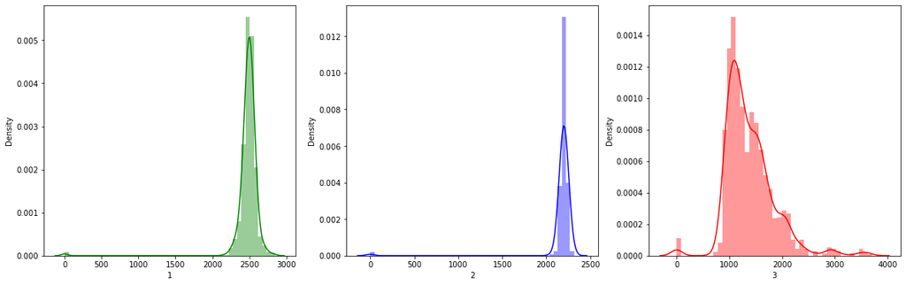

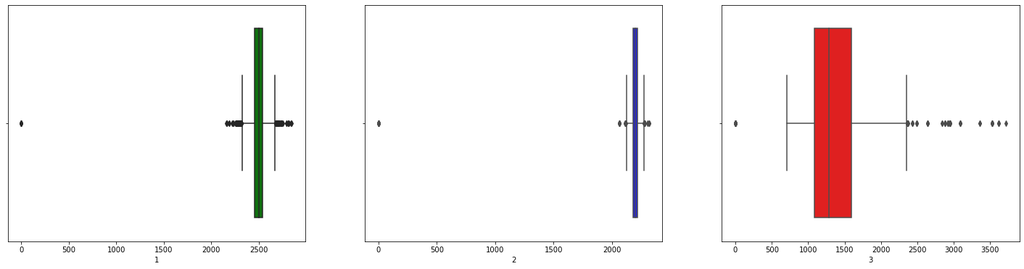

```python
plt.figure(figsize=(20,6))
plt.subplot(1, 3, 1)

sns.distplot(df['1'],color='green')


plt.subplot(1, 3, 2)

sns.distplot(df['2'],color='blue')


plt.subplot(1, 3, 3)

sns.distplot(df['3'],color='red')


plt.figure(figsize=(25,6))
plt.subplot(1, 3, 1)

sns.boxplot(df['1'],color='green')


plt.subplot(1, 3, 2)

sns.boxplot(df['2'],color='blue')


plt.subplot(1, 3, 3)

sns.boxplot(df['3'],color='red')

plt.show()
```

The distribution is nearly normal.There are many outliers in the data.

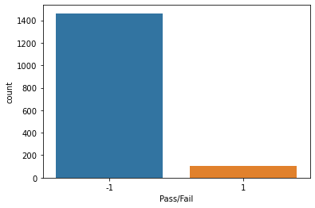

```python
sns.countplot(df['Pass/Fail'])
```

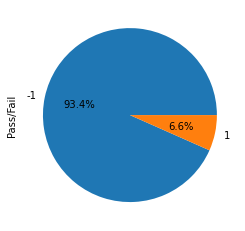

```python
df['Pass/Fail'].value_counts().plot.pie(autopct='%1.1f%%')
```

As the target is imbalanced we will go for sampling techniques for better prediction.

Handling outliers:

```python
for c in df.drop(columns='Pass/Fail').columns:
    #getting upper lower quartile values
    q1= df[c].quantile(0.25)
    q3 = df[c].quantile(0.75)

    IQR=q3-q1 #Interquartile range

    lower=q1-IQR*1.5
    upper=q3+IQR*1.5

    Outliers=[i for i in df[c] if i < lower or i > upper]

    #Calculating mean of the columns ignoring outliers

    df_include = df.loc[(df[c] >= lower) & (df[c] <= upper)]

    mean=int(df_include[c].mean())

    #imputing outliers with mean

    df[c]=np.where(df[c]>upper,mean,df[c])
    df[c]=np.where(df[c]<lower,mean,df[c])
```

Correlation Analysis:

```python
cor_matrix=df.corr()
```

```python
upper_tri = cor_matrix.where(np.triu(np.ones(cor_matrix.shape),k=1).astype(np.bool))
#print(upper_tri)
```

```python
to_drop = [column for column in upper_tri.columns if any(upper_tri[column] > 0.7)]
print()
print(to_drop)
```

```
['18', '25', '27', '30', '31', '46', '50', '51', '54', '60', '62', '65', '66', '70', '101', '123', '124', '127', '153', '154', '169', '174', '187', '201', '202', '203', '247', '250', '270', '271', '272', '273', '274', '275', '277', '278', '279', '280', '282', '283', '285', '286', '287', '288', '289'…
```

```python
len(to_drop)
```

```
198
```

```python
df1=df.copy(deep=True)
```

Dropping features having high correlation:

```python
df1.drop(to_drop,axis=1,inplace=True)
```

```python
df1.shape
```

```
(1567, 365)
```

```python
df1.describe()
```

|  | 0 | 1 | 2 | 3 | 4 | 5 | 6 | 7 | 8 | 9 | ... | 573 | 577 | 582 | 583 | 584 | 586 | 587 | 588 | 589 | Pass/Fail |
| --- | --- | --- | --- | --- | --- | --- | --- | --- | --- | --- | --- | --- | --- | --- | --- | --- | --- | --- | --- | --- | --- |
| count | 1567.000000 | 1567.000000 | 1567.000000 | 1567.000000 | 1567.000000 | 1567.0 | 1567.000000 | 1567.000000 | 1567.000000 | 1567.000000 | ... | 1567.000000 | 1567.000000 | 1567.000000 | 1567.000000 | 1567.000000 | 1567.000000 | 1567.000000 | 1567.000000 | 1567.000000 | 1567.000000 |
| mean | 3009.661327 | 2496.713242 | 2200.784654 | 1347.207674 | 1.283960 | 100.0 | 101.362866 | 0.120818 | 1.461410 | -0.001361 | ... | 0.273376 | 13.929698 | 0.496264 | 0.013185 | 0.003467 | 0.020142 | 0.014789 | 0.004705 | 76.785935 | -0.867262 |
| std | 62.052181 | 60.059448 | 26.103856 | 334.097293 | 0.338211 | 0.0 | 4.569489 | 0.014210 | 0.079543 | 0.013847 | ... | 0.111968 | 3.829828 | 0.043729 | 0.004414 | 0.000974 | 0.010608 | 0.007201 | 0.002334 | 45.400004 | 0.498010 |
| min | 2829.840000 | 2321.450000 | 2124.844400 | 711.025800 | 0.681500 | 100.0 | 87.741100 | 0.000000 | 1.000000 | -0.039300 | ... | 0.000000 | 4.582000 | 0.000000 | 0.000000 | 0.000000 | -0.006000 | 0.000000 | 0.000000 | 0.000000 | -1.000000 |
| 25% | 2968.000000 | 2459.590000 | 2182.555500 | 1084.377900 | 1.000000 | 100.0 | 98.756700 | 0.121100 | 1.410950 | -0.010650 | ... | 0.218650 | 11.501550 | 0.497900 | 0.011100 | 0.003000 | 0.012300 | 0.009800 | 0.003200 | 44.368600 | -1.000000 |
| 50% | 3009.000000 | 2496.000000 | 2200.200000 | 1287.353800 | 1.295500 | 100.0 | 101.217800 | 0.122300 | 1.461500 | -0.001200 | ... | 0.279600 | 13.283000 | 0.500100 | 0.013300 | 0.003500 | 0.020000 | 0.013900 | 0.004300 | 71.778000 | -1.000000 |
| 75% | 3051.840000 | 2534.555000 | 2217.666700 | 1551.694700 | 1.490500 | 100.0 | 104.249450 | 0.123800 | 1.516850 | 0.007600 | ... | 0.343250 | 16.312050 | 0.502300 | 0.015800 | 0.004000 | 0.027400 | 0.019000 | 0.006000 | 93.800800 | -1.000000 |
| max | 3190.970000 | 2669.090000 | 2273.755600 | 2347.909200 | 2.244900 | 100.0 | 114.585600 | 0.127600 | 1.656400 | 0.036200 | ... | 0.553400 | 25.355700 | 0.509000 | 0.023700 | 0.005600 | 0.048400 | 0.034500 | 0.010800 | 220.037800 | 1.000000 |

8 rows × 365 columns

```python
X=df1.drop(columns='Pass/Fail')
y=df1['Pass/Fail']
```

```python
X_train, X_test, y_train, y_test = train_test_split(X, y,stratify = y,test_size=0.30, random_state=10)
```

```python
X_train.describe()
```

|  | 0 | 1 | 2 | 3 | 4 | 5 | 6 | 7 | 8 | 9 | ... | 572 | 573 | 577 | 582 | 583 | 584 | 586 | 587 | 588 | 589 |
| --- | --- | --- | --- | --- | --- | --- | --- | --- | --- | --- | --- | --- | --- | --- | --- | --- | --- | --- | --- | --- | --- |
| count | 1096.000000 | 1096.000000 | 1096.000000 | 1096.000000 | 1096.000000 | 1096.0 | 1096.000000 | 1096.000000 | 1096.000000 | 1096.000000 | ... | 1096.000000 | 1096.000000 | 1096.000000 | 1096.000000 | 1096.000000 | 1096.000000 | 1096.000000 | 1096.000000 | 1096.000000 | 1096.000000 |
| mean | 3011.539215 | 2497.500164 | 2201.196400 | 1353.340524 | 1.293621 | 100.0 | 101.279996 | 0.121220 | 1.459024 | -0.001174 | ... | 8.591541 | 0.271923 | 13.839958 | 0.495467 | 0.013082 | 0.003461 | 0.020262 | 0.014777 | 0.004656 | 75.690532 |
| std | 61.404995 | 60.688341 | 26.511353 | 332.191920 | 0.342855 | 0.0 | 4.568690 | 0.012361 | 0.078934 | 0.013927 | ... | 1.687095 | 0.109102 | 3.741907 | 0.047672 | 0.004495 | 0.000990 | 0.010622 | 0.007107 | 0.002310 | 44.446557 |
| min | 2829.840000 | 2323.340000 | 2124.844400 | 711.025800 | 0.681500 | 100.0 | 87.741100 | 0.000000 | 1.000000 | -0.037600 | ... | 4.840000 | 0.000000 | 5.098600 | 0.000000 | 0.000000 | 0.000000 | -0.006000 | 0.000000 | 0.000000 | 0.000000 |
| 25% | 2971.912500 | 2459.345000 | 2182.947250 | 1089.365500 | 1.000000 | 100.0 | 98.590000 | 0.121000 | 1.408750 | -0.010325 | ... | 7.507500 | 0.222000 | 11.466950 | 0.497800 | 0.010975 | 0.003000 | 0.013100 | 0.009800 | 0.003175 | 44.368600 |
| 50% | 3009.000000 | 2496.605000 | 2200.955600 | 1288.250400 | 1.296900 | 100.0 | 101.353350 | 0.122400 | 1.458500 | -0.001000 | ... | 8.390000 | 0.276350 | 13.155300 | 0.500050 | 0.013100 | 0.003500 | 0.020100 | 0.013900 | 0.004300 | 71.010800 |
| 75% | 3053.345000 | 2537.465000 | 2218.055500 | 1551.694700 | 1.512000 | 100.0 | 104.172200 | 0.123800 | 1.515075 | 0.008000 | ... | 9.812500 | 0.338400 | 16.010500 | 0.502200 | 0.015700 | 0.004000 | 0.027400 | 0.019000 | 0.006000 | 91.426400 |
| max | 3190.970000 | 2669.090000 | 2273.755600 | 2341.783300 | 2.244900 | 100.0 | 114.585600 | 0.127600 | 1.656400 | 0.036200 | ... | 13.810000 | 0.553400 | 25.355700 | 0.509000 | 0.023700 | 0.005600 | 0.048400 | 0.034500 | 0.010800 | 220.037800 |

8 rows × 364 columns

```python
X_test.describe()
```

|  | 0 | 1 | 2 | 3 | 4 | 5 | 6 | 7 | 8 | 9 | ... | 572 | 573 | 577 | 582 | 583 | 584 | 586 | 587 | 588 | 589 |
| --- | --- | --- | --- | --- | --- | --- | --- | --- | --- | --- | --- | --- | --- | --- | --- | --- | --- | --- | --- | --- | --- |
| count | 471.000000 | 471.000000 | 471.000000 | 471.000000 | 471.000000 | 471.0 | 471.000000 | 471.000000 | 471.000000 | 471.000000 | ... | 471.000000 | 471.000000 | 471.000000 | 471.000000 | 471.000000 | 471.000000 | 471.000000 | 471.000000 | 471.000000 | 471.000000 |
| mean | 3005.291550 | 2494.882102 | 2199.826537 | 1332.936755 | 1.261481 | 100.0 | 101.555701 | 0.119880 | 1.466963 | -0.001795 | ... | 8.585391 | 0.276759 | 14.138520 | 0.498118 | 0.013426 | 0.003481 | 0.019864 | 0.014816 | 0.004821 | 79.334899 |
| std | 63.383404 | 58.592575 | 25.131533 | 338.414578 | 0.326399 | 0.0 | 4.570381 | 0.017765 | 0.080755 | 0.013663 | ... | 1.645952 | 0.118419 | 4.023343 | 0.032738 | 0.004215 | 0.000937 | 0.010582 | 0.007425 | 0.002388 | 47.495427 |
| min | 2831.180000 | 2321.450000 | 2124.844400 | 711.025800 | 0.681500 | 100.0 | 87.741100 | 0.000000 | 1.000000 | -0.039300 | ... | 4.920000 | 0.000000 | 4.582000 | 0.000000 | 0.000000 | 0.000000 | -0.006000 | 0.000000 | 0.000000 | 0.000000 |
| 25% | 2958.470000 | 2461.600000 | 2180.966600 | 1068.508250 | 1.000000 | 100.0 | 99.026700 | 0.121100 | 1.419350 | -0.010900 | ... | 7.490000 | 0.205750 | 11.822500 | 0.498100 | 0.011500 | 0.003100 | 0.012100 | 0.010150 | 0.003300 | 44.177450 |
| 50% | 3006.230000 | 2496.000000 | 2200.000000 | 1281.786200 | 1.280300 | 100.0 | 101.147800 | 0.122300 | 1.469200 | -0.001600 | ... | 8.420000 | 0.284800 | 13.578900 | 0.500300 | 0.013600 | 0.003600 | 0.019600 | 0.014200 | 0.004500 | 75.189700 |
| 75% | 3047.460000 | 2527.955000 | 2216.594450 | 1551.694700 | 1.429650 | 100.0 | 104.348350 | 0.123800 | 1.524000 | 0.006900 | ... | 9.695000 | 0.358600 | 16.863600 | 0.502650 | 0.016050 | 0.004000 | 0.027500 | 0.018900 | 0.006150 | 102.524100 |
| max | 3185.690000 | 2662.700000 | 2270.255600 | 2347.909200 | 2.207900 | 100.0 | 114.553300 | 0.127600 | 1.622700 | 0.034300 | ... | 13.760000 | 0.544100 | 24.354100 | 0.508800 | 0.023300 | 0.005600 | 0.048400 | 0.034500 | 0.010800 | 220.037800 |

8 rows × 364 columns

We can see that train and test data have similar statistical characteristics when compared with original data.

```python
from sklearn.preprocessing import StandardScaler

# creating a standard scaler
sc = StandardScaler()

# fitting independent data to the model
X_train = sc.fit_transform(X_train)
X_test = sc.fit_transform(X_test)
```

```python
X_train1=X_train
X_test1=X_test
y_train1=y_train
y_test1=y_test
```

# Model building

```python
logreg = LogisticRegression()

logreg.fit(X_train, y_train)

lr_score = logreg.score(X_test, y_test)
print(f"Score : {lr_score}")

pred = logreg.predict(X_test)
tn, fp, fn, tp =confusion_matrix(y_test,pred).ravel()

lr_recall = round(tp/(tp+fn), 3)   # Of all the people with Chd, how many were recognised to have Chd
lr_precision = round(tp/(tp+fp), 3)  # Of all the people predicted to have Chd, how many did have Chd
lr_specificity =round(tn/(tn+fp),3)    # Of all the people without Chds, how many were recognised to not have Chd
type_1_error = fp    # People without Chd predicted to have Chd
type_2_error = fn    # People with Chd predicted to have no Chd

lr_recall, lr_precision, lr_specificity, type_1_error, type_2_error
```

```
Score : 0.8662420382165605
```

```
(0.258, 0.167, 0.909, 40, 23)
```

```
AUC: 0.734
```

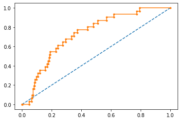

```python
probs = logreg.predict_proba(X_test)
# keep probabilities for the positive outcome only
probs = probs[:, 1]
# calculate AUC
auc = roc_auc_score(y_test, probs)
print('AUC: %.3f' % auc)
# calculate roc curve
fpr, tpr, thresholds = roc_curve(y_test, probs)
# plot no skill
plt.plot([0, 1], [0, 1], linestyle='--')
# plot the roc curve for the model
plt.plot(fpr, tpr, marker='.')
# show the plot
plt.show()
```

```python
### Random forest

from sklearn.ensemble import RandomForestClassifier

rf = RandomForestClassifier(n_estimators=100, max_depth=5, random_state=1)
rf.fit(X_train, y_train)

rf_score = rf.score(X_test, y_test)
print(f"Score : {rf_score}")

pred = rf.predict(X_test)

tn, fp, fn, tp = confusion_matrix(y_test,pred).ravel()

rf_recall = round(tp/(tp+fn), 3)
rf_precision = round(tp/(tp+fp), 3)
rf_specificity =round(tn/(tn+fp),3)
rf_type_1_error = fp
rf_type_2_error = fn

rf_recall, rf_precision, rf_specificity, rf_type_1_error, rf_type_2_error
```

```
Score : 0.9341825902335457
```

```
(0.0, nan, 1.0, 0, 31)
```

```
AUC: 0.737
```

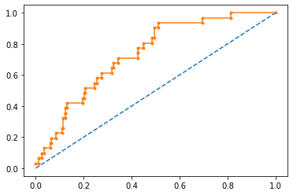

```python
probs = rf.predict_proba(X_test)
# keep probabilities for the positive outcome only
probs = probs[:, 1]
# calculate AUC
auc = roc_auc_score(y_test, probs)
print('AUC: %.3f' % auc)
# calculate roc curve
fpr, tpr, thresholds = roc_curve(y_test, probs)
# plot no skill
plt.plot([0, 1], [0, 1], linestyle='--')
# plot the roc curve for the model
plt.plot(fpr, tpr, marker='.')
# show the plot
plt.show()
```

```python
#Applying  GridSearchCV on Random Forest
```

```python
from sklearn.model_selection import GridSearchCV

parameters = {'bootstrap': [True],
 'max_depth': [10, 20, 30, 40, 50],
 'max_features': ['auto', 'sqrt'],
 'min_samples_leaf': [1, 2, 4, 8],
 'n_estimators': [100]}


clf = GridSearchCV(RandomForestClassifier(), parameters, cv = 5, verbose = 2, n_jobs= 4)
clf.fit(X, y)

clf.best_params_
```

```
Fitting 5 folds for each of 40 candidates, totalling 200 fits
```

```
[Parallel(n_jobs=4)]: Done  33 tasks      | elapsed:   13.9s
[Parallel(n_jobs=4)]: Done 154 tasks      | elapsed:   55.7s
[Parallel(n_jobs=4)]: Done 200 out of 200 | elapsed:  1.2min finished
```

```
{'bootstrap': True,
 'max_depth': 10,
 'max_features': 'auto',
 'min_samples_leaf': 2,
 'n_estimators': 100}
```

```python
from sklearn.model_selection import cross_val_score
rf = RandomForestClassifier(bootstrap= True,
 max_depth= 10,
 max_features= 'auto',
 min_samples_leaf= 4,
 n_estimators= 100)

rf.fit(X_train, y_train)

score= cross_val_score(rf, X_train, y_train, cv = 5).mean()


score
```

```
0.9334028356964137
```

```python
xgb = XGBClassifier(random_state=1)
xgb.fit(X_train, y_train)
xgb_score = xgb.score(X_test, y_test)
pred = xgb.predict(X_test)

tn, fp, fn, tp = confusion_matrix(y_test,pred).ravel()

xgb_recall = round(tp/(tp+fn), 3)
xgb_precision = round(tp/(tp+fp), 3)
xgb_specificity =round(tn/(tn+fp),3)
xgb_type_1_error = fp
xgb_type_2_error = fn

print(f"Score : {xgb_score}")
xgb_recall, xgb_precision, xgb_specificity
```

[output not shown]

```
(0.0, nan, 1.0)
```

Random forest and XGBoost are giving highest accuracy but recall and precision is low

# #Comparing different models together

# Data without sampling and PCA:

```
LR
             precision    recall  f1-score   support

         -1       0.95      0.91      0.93       440
          1       0.17      0.26      0.20        31

avg / total       0.89      0.87      0.88       471

XGB
             precision    recall  f1-score   support

         -1       0.93      1.00      0.97       440
          1       0.00      0.00      0.00        31

avg / total       0.87      0.93      0.90       471

KNN
             precision    recall  f1-score   support

         -1       0.93      1.00      0.96       440
          1       0.00      0.00      0.00        31

avg / total       0.87      0.93      0.90       471

DT
             precision    recall  f1-score   support

         -1       0.93      0.98      0.96       440
          1       0.00      0.00      0.00        31

avg / total       0.87      0.92      0.89       471

RF
             precision    recall  f1-score   support

         -1       0.93      1.00      0.97       440
          1       0.00      0.00      0.00        31

avg / total       0.87      0.93      0.90       471

ADA
             precision    recall  f1-score   support

         -1       0.94      0.99      0.96       440
          1       0.25      0.03      0.06        31

avg / total       0.89      0.93      0.90       471

SVC
             precision    recall  f1-score   support

         -1       0.93      1.00      0.97       440
          1       0.00      0.00      0.00        31

avg / total       0.87      0.93      0.90       471
```

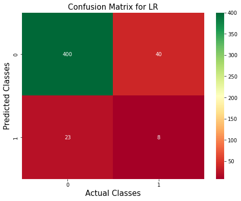

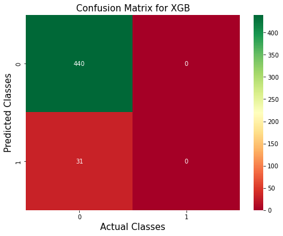

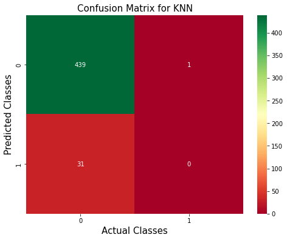

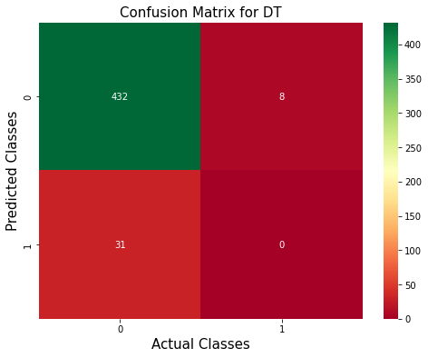

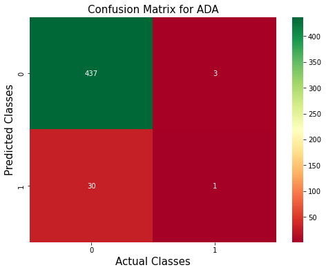

```python
xgb = XGBClassifier()
logreg= LogisticRegression()
knn = KNeighborsClassifier()
svcl = SVC()

adb = AdaBoostClassifier()

dtclf =DecisionTreeClassifier()
rfclf =RandomForestClassifier()



#prepare configuration for cross validation test harness
seed = 42

# prepare models

models = []
models.append(('LR', LogisticRegression()))
models.append(('XGB', XGBClassifier(random_state=1, eval_metric='mlogloss')))
models.append(('KNN', KNeighborsClassifier(5)))
models.append(('DT', DecisionTreeClassifier(max_depth=5)))
models.append(('RF', RandomForestClassifier(n_estimators=196)))
models.append(('ADA', AdaBoostClassifier()))
models.append(('SVC', SVC()))
xgb = XGBClassifier()
logreg= LogisticRegression()
knn = KNeighborsClassifier()
svcl = SVC()

adb = AdaBoostClassifier()

dtclf =DecisionTreeClassifier()
rfclf =RandomForestClassifier()


#prepare configuration for cross validation test harness
seed = 42

# prepare models

models = []
models.append(('LR', LogisticRegression()))
models.append(('XGB', XGBClassifier(random_state=1, eval_metric='mlogloss')))
models.append(('KNN', KNeighborsClassifier(5)))
models.append(('DT', DecisionTreeClassifier(max_depth=5)))
models.append(('RF', RandomForestClassifier(n_estimators=196)))
models.append(('ADA', AdaBoostClassifier()))
models.append(('SVC', SVC()))


#evaluate each model in turn

results = []
names = []
scoring = 'accuracy'
precision=[]
recall=[]

for name, model in models:

    clf = model.fit(X_train, y_train)
    pred = clf.predict(X_test)

    cv_results=accuracy_score(y_test, pred)


    tn, fp, fn, tp = confusion_matrix(y_test,pred).ravel()
        #visualization of confusion matrix in the form of a heatmap

    cm= confusion_matrix(y_test, pred)
    plt.figure(figsize = (8, 6))
    sns.heatmap(cm, annot = True, cmap = 'RdYlGn', fmt = 'd')
    plt.xlabel('Actual Classes', fontsize = 15)
    plt.ylabel('Predicted Classes', fontsize = 15)
    plt.title('Confusion Matrix for '+ str(name), fontsize = 15);
    plt.show
    print(name)
    print(classification_report(y_test, pred))

    recallv = round(tp/(tp+fn), 3)
    precisionv = round(tp/(tp+fp), 3)
    recall.append(recallv)
    precision.append(precisionv)

    results.append(cv_results)
    names.append(name)
    msg = "%s: %f %f %f" % (name, cv_results.mean(), precisionv,recallv)
   # print(msg)
```

```python
result = pd.DataFrame({'Model' :
                           names,
                       'Accuracy' : results,
                      'Recall' : recall,
                      'Precision' : precision,
                      })
result
```

|  | Model | Accuracy | Recall | Precision |
| --- | --- | --- | --- | --- |
| 0 | LR | 0.866242 | 0.258 | 0.167 |
| 1 | XGB | 0.934183 | 0.000 | NaN |
| 2 | KNN | 0.932059 | 0.000 | 0.000 |
| 3 | DT | 0.917197 | 0.000 | 0.000 |
| 4 | RF | 0.934183 | 0.000 | NaN |
| 5 | ADA | 0.929936 | 0.032 | 0.250 |
| 6 | SVC | 0.934183 | 0.000 | NaN |

Accuracy is good for all the models but precision and recall are very low.They are not correctly predicting the class 2. So we will go for sampling techniques.

# Data with SMOTE

Applying SMOTE for oversampling

```python
from imblearn.over_sampling import SMOTE

#sm = SMOTE(random_state=42)

#X_train, y_train = sm.fit_sample(X_train, y_train)
```

```python
X_train.shape
```

```
(1096, 364)
```

```python
print("Before UpSampling, counts of label '1': {}".format(sum(y_train==1)))
print("Before UpSampling, counts of label '-1': {} \n".format(sum(y_train==-1)))

sm = SMOTE(k_neighbors = 5, random_state=1)   #Synthetic Minority Over Sampling Technique
X_train_res, y_train_res = sm.fit_sample(X_train, y_train.ravel())


print("After UpSampling, counts of label '1': {}".format(sum(y_train_res==1)))
print("After UpSampling, counts of label '-1': {} \n".format(sum(y_train_res==-1)))



print('After UpSampling, the shape of train_X: {}'.format(X_train_res.shape))
print('After UpSampling, the shape of train_y: {} \n'.format(y_train_res.shape))
```

```
Before UpSampling, counts of label '1': 73
Before UpSampling, counts of label '-1': 1023

After UpSampling, counts of label '1': 1023
After UpSampling, counts of label '-1': 1023

After UpSampling, the shape of train_X: (2046, 364)
After UpSampling, the shape of train_y: (2046,)
```

```
LR
             precision    recall  f1-score   support

         -1       0.95      0.84      0.89       440
          1       0.15      0.39      0.21        31

avg / total       0.90      0.81      0.85       471

XGB
             precision    recall  f1-score   support

         -1       0.94      0.84      0.89       440
          1       0.11      0.29      0.16        31

avg / total       0.89      0.80      0.84       471

KNN
             precision    recall  f1-score   support

         -1       1.00      0.13      0.23       440
          1       0.07      1.00      0.14        31

avg / total       0.94      0.19      0.22       471

DT
             precision    recall  f1-score   support

         -1       0.94      0.64      0.76       440
          1       0.08      0.45      0.14        31

avg / total       0.89      0.63      0.72       471

RF
             precision    recall  f1-score   support

         -1       0.93      1.00      0.97       440
          1       0.00      0.00      0.00        31

avg / total       0.87      0.93      0.90       471

ADA
             precision    recall  f1-score   support

         -1       0.93      0.83      0.88       440
          1       0.06      0.16      0.09        31

avg / total       0.88      0.78      0.83       471

SVC
             precision    recall  f1-score   support

         -1       0.93      0.99      0.96       440
          1       0.00      0.00      0.00        31

avg / total       0.87      0.93      0.90       471
```

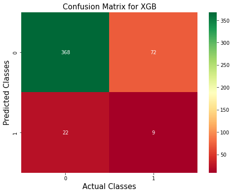

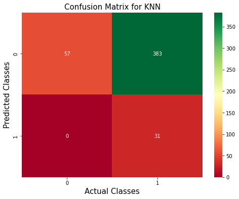

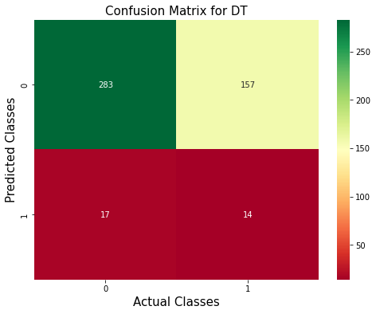

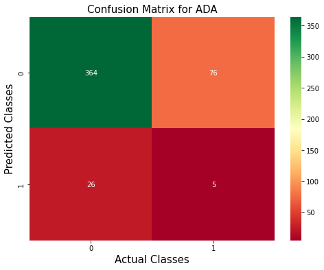

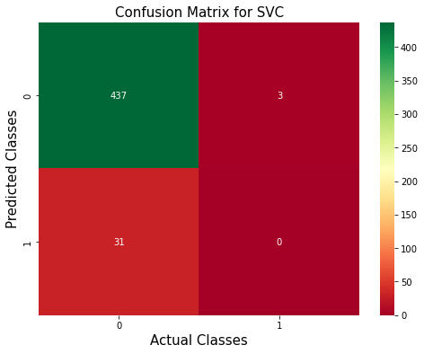

```python
xgb = XGBClassifier()
logreg= LogisticRegression()
knn = KNeighborsClassifier()
svcl = SVC()

adb = AdaBoostClassifier()

dtclf =DecisionTreeClassifier()
rfclf =RandomForestClassifier()



#prepare configuration for cross validation test harness
seed = 42

# prepare models

models = []
models.append(('LR', LogisticRegression()))
models.append(('XGB', XGBClassifier(random_state=1, eval_metric='mlogloss')))
models.append(('KNN', KNeighborsClassifier(5)))
models.append(('DT', DecisionTreeClassifier(max_depth=5)))
models.append(('RF', RandomForestClassifier(n_estimators=196)))
models.append(('ADA', AdaBoostClassifier()))
models.append(('SVC', SVC()))
xgb = XGBClassifier()
logreg= LogisticRegression()
knn = KNeighborsClassifier()
svcl = SVC()

adb = AdaBoostClassifier()

dtclf =DecisionTreeClassifier()
rfclf =RandomForestClassifier()


#prepare configuration for cross validation test harness
seed = 42

# prepare models

models = []
models.append(('LR', LogisticRegression()))
models.append(('XGB', XGBClassifier(random_state=1, eval_metric='mlogloss')))
models.append(('KNN', KNeighborsClassifier(5)))
models.append(('DT', DecisionTreeClassifier(max_depth=5)))
models.append(('RF', RandomForestClassifier(n_estimators=196)))
models.append(('ADA', AdaBoostClassifier()))
models.append(('SVC', SVC()))


#evaluate each model in turn

results = []
names = []
scoring = 'accuracy'
precision=[]
recall=[]

for name, model in models:

    clf = model.fit(X_train_res, y_train_res)
    pred = clf.predict(X_test)

    cv_results=accuracy_score(y_test, pred)


    tn, fp, fn, tp = confusion_matrix(y_test,pred).ravel()
        #visualization of confusion matrix in the form of a heatmap

    cm= confusion_matrix(y_test, pred)
    plt.figure(figsize = (8, 6))
    sns.heatmap(cm, annot = True, cmap = 'RdYlGn', fmt = 'd')
    plt.xlabel('Actual Classes', fontsize = 15)
    plt.ylabel('Predicted Classes', fontsize = 15)
    plt.title('Confusion Matrix for '+ str(name), fontsize = 15);
    plt.show
    print(name)
    print(classification_report(y_test, pred))

    recallv = round(tp/(tp+fn), 3)
    precisionv = round(tp/(tp+fp), 3)
    recall.append(recallv)
    precision.append(precisionv)

    results.append(cv_results)
    names.append(name)
    msg = "%s: %f %f %f" % (name, cv_results.mean(), precisionv,recallv)
   # print(msg)
```

```python
#confusion_matrix(y_test,pred).ravel()
```

```python
result_sm = pd.DataFrame({'Model' : names,
                       'Accuracy' : results,
                      'Recall' : recall,
                      'Precision' : precision,
                      })
result_sm
```

|  | Model | Accuracy | Recall | Precision |
| --- | --- | --- | --- | --- |
| 0 | LR | 0.813163 | 0.387 | 0.148 |
| 1 | XGB | 0.800425 | 0.290 | 0.111 |
| 2 | KNN | 0.186837 | 1.000 | 0.075 |
| 3 | DT | 0.630573 | 0.452 | 0.082 |
| 4 | RF | 0.934183 | 0.000 | NaN |
| 5 | ADA | 0.783439 | 0.161 | 0.062 |
| 6 | SVC | 0.927813 | 0.000 | 0.000 |

# Data with Random Oversampling:

```python
from imblearn.over_sampling import RandomOverSampler

# Apply RandomOverSampler to balance the dataset
os =  RandomOverSampler()
X_train_os, y_train_os = os.fit_sample(X_train, y_train)

# New count after balancing -> {0: 900, 1: 900}
#print('Resampled dataset shape {}'.format(Counter( y_train)))
```

```
LR
             precision    recall  f1-score   support

         -1       0.95      0.84      0.89       440
          1       0.15      0.39      0.21        31

avg / total       0.90      0.81      0.85       471

XGB
             precision    recall  f1-score   support

         -1       0.93      1.00      0.96       440
          1       0.00      0.00      0.00        31

avg / total       0.87      0.93      0.90       471

KNN
             precision    recall  f1-score   support

         -1       0.95      0.86      0.90       440
          1       0.14      0.32      0.19        31

avg / total       0.89      0.82      0.85       471

DT
             precision    recall  f1-score   support

         -1       0.94      0.73      0.83       440
          1       0.09      0.39      0.15        31

avg / total       0.89      0.71      0.78       471

RF
             precision    recall  f1-score   support

         -1       0.93      1.00      0.97       440
          1       0.00      0.00      0.00        31

avg / total       0.87      0.93      0.90       471

ADA
             precision    recall  f1-score   support

         -1       0.93      0.91      0.92       440
          1       0.07      0.10      0.08        31

avg / total       0.88      0.86      0.87       471

SVC
             precision    recall  f1-score   support

         -1       0.93      0.99      0.96       440
          1       0.00      0.00      0.00        31

avg / total       0.87      0.93      0.90       471
```

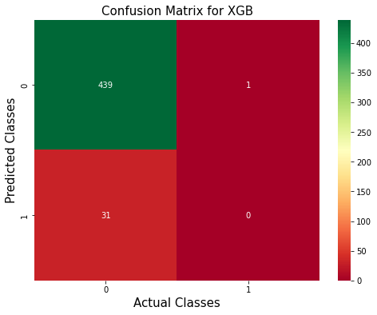

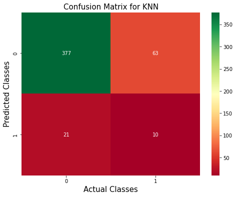

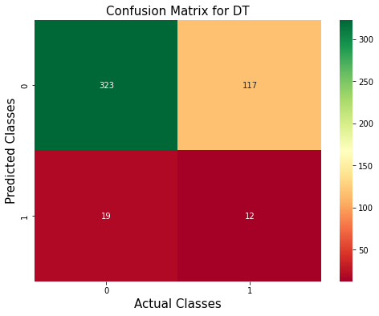

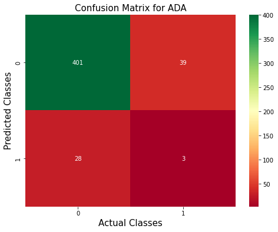

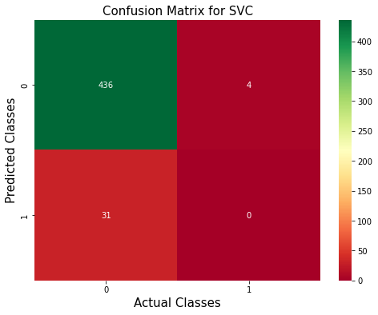

```python
xgb = XGBClassifier()
logreg= LogisticRegression()
knn = KNeighborsClassifier()
svcl = SVC()

adb = AdaBoostClassifier()

dtclf =DecisionTreeClassifier()
rfclf =RandomForestClassifier()



#prepare configuration for cross validation test harness
seed = 42

# prepare models

models = []
models.append(('LR', LogisticRegression()))
models.append(('XGB', XGBClassifier(random_state=1, eval_metric='mlogloss')))
models.append(('KNN', KNeighborsClassifier(5)))
models.append(('DT', DecisionTreeClassifier(max_depth=5)))
models.append(('RF', RandomForestClassifier(n_estimators=196)))
models.append(('ADA', AdaBoostClassifier()))
models.append(('SVC', SVC()))
xgb = XGBClassifier()
logreg= LogisticRegression()
knn = KNeighborsClassifier()
svcl = SVC()

adb = AdaBoostClassifier()

dtclf =DecisionTreeClassifier()
rfclf =RandomForestClassifier()


#prepare configuration for cross validation test harness
seed = 42

# prepare models

models = []
models.append(('LR', LogisticRegression()))
models.append(('XGB', XGBClassifier(random_state=1, eval_metric='mlogloss')))
models.append(('KNN', KNeighborsClassifier(5)))
models.append(('DT', DecisionTreeClassifier(max_depth=5)))
models.append(('RF', RandomForestClassifier(n_estimators=196)))
models.append(('ADA', AdaBoostClassifier()))
models.append(('SVC', SVC()))


#evaluate each model in turn

results = []
names = []
scoring = 'accuracy'
precision=[]
recall=[]

for name, model in models:

    clf = model.fit(X_train_os, y_train_os)
    pred = clf.predict(X_test)

    cv_results=accuracy_score(y_test, pred)


    tn, fp, fn, tp = confusion_matrix(y_test,pred).ravel()
        #visualization of confusion matrix in the form of a heatmap

    cm= confusion_matrix(y_test, pred)
    plt.figure(figsize = (8, 6))
    sns.heatmap(cm, annot = True, cmap = 'RdYlGn', fmt = 'd')
    plt.xlabel('Actual Classes', fontsize = 15)
    plt.ylabel('Predicted Classes', fontsize = 15)
    plt.title('Confusion Matrix for '+ str(name), fontsize = 15);
    plt.show
    print(name)
    print(classification_report(y_test, pred))

    recallv = round(tp/(tp+fn), 3)
    precisionv = round(tp/(tp+fp), 3)
    recall.append(recallv)
    precision.append(precisionv)

    results.append(cv_results)
    names.append(name)
    msg = "%s: %f %f %f" % (name, cv_results.mean(), precisionv,recallv)
   # print(msg)
```

```python
result_os = pd.DataFrame({'Model' : names,
                       'Accuracy' : results,
                      'Recall' : recall,
                      'Precision' : precision,
                      })
result_os
```

|  | Model | Accuracy | Recall | Precision |
| --- | --- | --- | --- | --- |
| 0 | LR | 0.813163 | 0.387 | 0.148 |
| 1 | XGB | 0.932059 | 0.000 | 0.000 |
| 2 | KNN | 0.821656 | 0.323 | 0.137 |
| 3 | DT | 0.711253 | 0.387 | 0.093 |
| 4 | RF | 0.934183 | 0.000 | NaN |
| 5 | ADA | 0.857749 | 0.097 | 0.071 |
| 6 | SVC | 0.925690 | 0.000 | 0.000 |

# Applying PCA

```python
from sklearn.preprocessing import StandardScaler

# creating a standard scaler
sc = StandardScaler()

# fitting independent data to the model
XScaled = sc.fit_transform(X)
#x_test = sc.transform(x_test)
```

```python
from sklearn.decomposition import PCA
```

```python
X.isnull().sum().sum()
```

```
0
```

```python
np.all(np.isfinite(X))
```

```
True
```

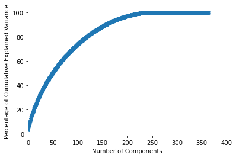

```python
#plotting the cummulative variance explained by the principal componets
pca = PCA()
X_pca_ = pca.fit_transform(XScaled)
#plt.figure(figsize = (12, 8))
plt.plot((np.cumsum(pca.explained_variance_ratio_) * 100), marker = 'X')
plt.xlim(0, 400)
plt.xlabel('Number of Components')
plt.ylabel('Percentage of Cumulative Explained Variance');
```

```python
#print(pca.explained_variance_)
```

```python
#Using 150 components and printing the eigen vectors
pca150 = PCA(n_components=150)
pca150.fit(XScaled)
print(pca150.components_)
print(pca150.explained_variance_ratio_)
Xpca150 = pca150.transform(XScaled)
```

```
[[-0.01726491  0.00260404 -0.00796557 ...  0.02036639  0.03169961
   0.01984243]
 [ 0.01333913 -0.02346577 -0.03363759 ...  0.01695932  0.00261567
  -0.01569293]
 [-0.04216952  0.01346289  0.04455219 ...  0.01540962  0.02795116
   0.09961207]
 ...
 [-0.00769145 -0.04724804  0.08910445 ...  0.04812366  0.06248057
  -0.00801911]
 [ 0.0523671  -0.04879413  0.11196418 ... -0.00499076  0.00955925
  -0.01186108]
 [ 0.05482011 -0.03413695 -0.02332931 ...  0.04221556 -0.03886188
   0.03908771]]
[0.03524493 0.02201415 0.02015996 0.0171281  0.01577203 0.01480252
 0.01321614 0.01269879 0.01222166 0.01215242 0.01170178 0.01135395
 0.01099744 0.01059146 0.01035639 0.01014164 0.01008501 0.00987458
 0.00973786 0.0096761  0.00919076 0.00892059 0.00885134 0.00872534
 0.00851025 0.00843442 0.00834208 0.00818057 0.00803964 0.00783073
 0.00778716 0.00766831 0.00753593 0.00749677 0.00736504 0.00728305
 0.00723554 0.00702907 0.00689962 0.00684881 0.00679892 0.00675326
 0.00661392 0.00656393 0.00646602 0.00644539 0.00630553 0.00622782
 0.00610928 0.00606446 0.00600683 0.00591253 0.00585592 0.00574018
 0.00562584 0.00557356 0.00552232 0.00544041 0.0053815  0.00533572
 0.00528633 0.00525652 0.00519374 0.0051831  0.00511575 0.00506853
 0.00502304 0.00500471 0.00495808 0.00492113 0.00486592 0.00481912
 0.00474009 0.00472896 0.00466984 0.00462436 0.00458069 0.00455437
 0.00448727 0.00447308 0.00441644 0.00438356 0.00433398 0.00429969
 0.00425286 0.00421196 0.00419169 0.00415639 0.00409946 0.00406087
 0.00404989 0.00400361 0.00399626 0.00392409 0.00388143 0.00382395
 0.00381691 0.00377052 0.00374745 0.0037262  0.00368143 0.00363932
 0.00358403 0.00356946 0.00354012 0.00351868 0.00348522 0.00344405
 0.00341554 0.00341419 0.00338527 0.00334104 0.00329164 0.00327424
 0.0032495  0.00323576 0.00318001 0.00315609 0.00312798 0.00311236
 0.00307394 0.00305866 0.00301023 0.00299175 0.00292586 0.00290884
 0.00288305 0.00283574 0.00280822 0.00278354 0.00277612 0.00273432
 0.00267898 0.00266935 0.0026459  0.00261323 0.00258692 0.00256918
 0.00252493 0.00246926 0.0024578  0.00241171 0.00239488 0.00235597
 0.00232403 0.00231001 0.00229962 0.00224098 0.00218868 0.0021765 ]
```

```python
#printing the original features and the reduced features
pca_0 = PCA(n_components =304 )
X_pca = pca_0.fit_transform(XScaled)
print('Original number of features:', X.shape[1])
print('Reduced number of features:', Xpca150.shape[1])
```

```
Original number of features: 364
Reduced number of features: 150
```

```python
#viewing the first 5 observations of the pca components
pca_df = pd.DataFrame(data = Xpca150)
pca_df.head()
```

|  | 0 | 1 | 2 | 3 | 4 | 5 | 6 | 7 | 8 | 9 | ... | 140 | 141 | 142 | 143 | 144 | 145 | 146 | 147 | 148 | 149 |
| --- | --- | --- | --- | --- | --- | --- | --- | --- | --- | --- | --- | --- | --- | --- | --- | --- | --- | --- | --- | --- | --- |
| 0 | 1.926073 | -2.094394 | -1.552870 | 0.851692 | -0.367031 | -1.253549 | -3.650081 | -4.407648 | 4.202676 | 0.776998 | ... | 0.755407 | 0.442690 | -0.476646 | -0.876622 | -0.571435 | 0.984410 | 1.220528 | -1.299841 | -0.259797 | -1.389422 |
| 1 | 0.866084 | -1.972365 | -0.069183 | 1.285283 | 0.472454 | -0.849131 | 1.809394 | -1.062167 | 2.653450 | -2.366407 | ... | -1.304217 | -1.321645 | 0.493081 | 0.018031 | 0.790507 | -0.074429 | -0.123480 | 0.081182 | -0.587909 | -0.520402 |
| 2 | 1.460307 | -1.703560 | 2.579286 | 0.336554 | -1.428258 | 0.188563 | 0.239192 | -0.836842 | 1.127460 | -1.909451 | ... | -0.536548 | 1.119199 | -0.084772 | -0.744210 | 0.541095 | 1.108936 | -0.518672 | 0.807019 | -0.125924 | -0.527148 |
| 3 | 1.469554 | -0.060739 | 2.003658 | 1.708871 | -1.840513 | -2.498805 | 0.999615 | 0.114986 | 2.726558 | -0.144014 | ... | -0.518381 | 1.016626 | -0.387655 | 0.434670 | -0.233649 | -0.257935 | 0.328069 | -0.652671 | 0.234601 | -1.464812 |
| 4 | 4.359758 | 0.023227 | 1.653856 | -1.206464 | 0.273771 | -3.426831 | 0.677555 | 3.461719 | 0.740084 | 0.824867 | ... | 0.120421 | -1.050374 | -0.997885 | 0.358848 | -0.608847 | 0.208950 | -0.850727 | 1.098985 | 0.102670 | -0.316341 |

5 rows × 150 columns

```python
X_train, X_test, y_train, y_test = train_test_split(Xpca150,y,stratify=y, test_size=0.30, random_state=10)
```

```
LR
             precision    recall  f1-score   support

         -1       0.94      0.96      0.95       440
          1       0.17      0.13      0.15        31

avg / total       0.89      0.90      0.90       471

XGB
             precision    recall  f1-score   support

         -1       0.93      1.00      0.97       440
          1       0.00      0.00      0.00        31

avg / total       0.87      0.93      0.90       471

KNN
             precision    recall  f1-score   support

         -1       0.93      1.00      0.96       440
          1       0.00      0.00      0.00        31

avg / total       0.87      0.93      0.90       471

DT
             precision    recall  f1-score   support

         -1       0.93      0.98      0.96       440
          1       0.00      0.00      0.00        31

avg / total       0.87      0.92      0.89       471

RF
             precision    recall  f1-score   support

         -1       0.93      1.00      0.97       440
          1       0.00      0.00      0.00        31

avg / total       0.87      0.93      0.90       471

ADA
             precision    recall  f1-score   support

         -1       0.94      0.97      0.95       440
          1       0.17      0.10      0.12        31

avg / total       0.89      0.91      0.90       471

SVC
             precision    recall  f1-score   support

         -1       0.93      1.00      0.97       440
          1       0.00      0.00      0.00        31

avg / total       0.87      0.93      0.90       471
```

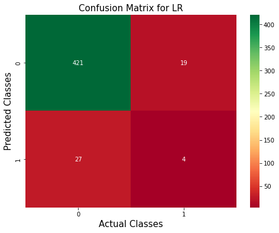

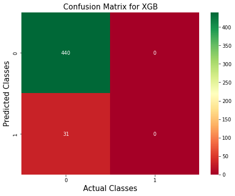

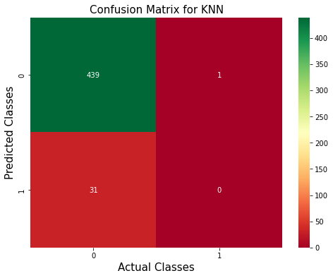

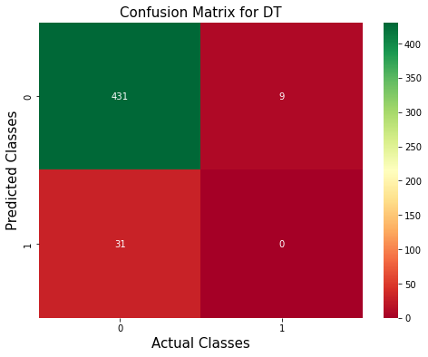

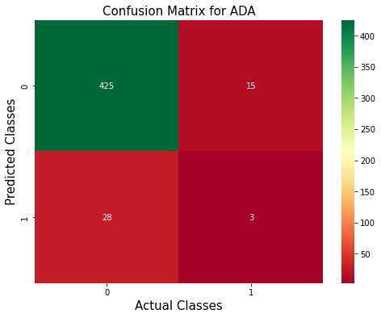

```python
xgb = XGBClassifier()
logreg= LogisticRegression()
knn = KNeighborsClassifier()
svcl = SVC()

adb = AdaBoostClassifier()

dtclf =DecisionTreeClassifier()
rfclf =RandomForestClassifier()



#prepare configuration for cross validation test harness
seed = 42

# prepare models

models = []
models.append(('LR', LogisticRegression()))
models.append(('XGB', XGBClassifier(random_state=1, eval_metric='mlogloss')))
models.append(('KNN', KNeighborsClassifier(5)))
models.append(('DT', DecisionTreeClassifier(max_depth=5)))
models.append(('RF', RandomForestClassifier(n_estimators=196)))
models.append(('ADA', AdaBoostClassifier()))
models.append(('SVC', SVC()))
xgb = XGBClassifier()
logreg= LogisticRegression()
knn = KNeighborsClassifier()
svcl = SVC()

adb = AdaBoostClassifier()

dtclf =DecisionTreeClassifier()
rfclf =RandomForestClassifier()


#prepare configuration for cross validation test harness
seed = 42

# prepare models

models = []
models.append(('LR', LogisticRegression()))
models.append(('XGB', XGBClassifier(random_state=1, eval_metric='mlogloss')))
models.append(('KNN', KNeighborsClassifier(5)))
models.append(('DT', DecisionTreeClassifier(max_depth=5)))
models.append(('RF', RandomForestClassifier(n_estimators=196)))
models.append(('ADA', AdaBoostClassifier()))
models.append(('SVC', SVC()))


#evaluate each model in turn

results = []
names = []
scoring = 'accuracy'
precision=[]
recall=[]

for name, model in models:

    clf = model.fit(X_train, y_train)
    pred = clf.predict(X_test)

    cv_results=accuracy_score(y_test, pred)


    tn, fp, fn, tp = confusion_matrix(y_test,pred).ravel()
        #visualization of confusion matrix in the form of a heatmap

    cm= confusion_matrix(y_test, pred)
    plt.figure(figsize = (8, 6))
    sns.heatmap(cm, annot = True, cmap = 'RdYlGn', fmt = 'd')
    plt.xlabel('Actual Classes', fontsize = 15)
    plt.ylabel('Predicted Classes', fontsize = 15)
    plt.title('Confusion Matrix for '+ str(name), fontsize = 15);
    plt.show
    print(name)
    print(classification_report(y_test, pred))

    recallv = round(tp/(tp+fn), 3)
    precisionv = round(tp/(tp+fp), 3)
    recall.append(recallv)
    precision.append(precisionv)

    results.append(cv_results)
    names.append(name)
    msg = "%s: %f %f %f" % (name, cv_results.mean(), precisionv,recallv)
   # print(msg)
```

```python
result_pca = pd.DataFrame({'Model' :
                           names,
                       'Accuracy' : results,
                      'Recall' : recall,
                      'Precision' : precision,
                      })
result_pca
```

|  | Model | Accuracy | Recall | Precision |
| --- | --- | --- | --- | --- |
| 0 | LR | 0.902335 | 0.129 | 0.174 |
| 1 | XGB | 0.934183 | 0.000 | NaN |
| 2 | KNN | 0.932059 | 0.000 | 0.000 |
| 3 | DT | 0.915074 | 0.000 | 0.000 |
| 4 | RF | 0.934183 | 0.000 | NaN |
| 5 | ADA | 0.908705 | 0.097 | 0.167 |
| 6 | SVC | 0.934183 | 0.000 | NaN |

# PCA with SMOTE:

```python
from imblearn.over_sampling import SMOTE

sm = SMOTE(random_state=42)

X_train, y_train = sm.fit_sample(X_train, y_train)
```

```
LR
             precision    recall  f1-score   support

         -1       0.96      0.80      0.87       440
          1       0.15      0.48      0.23        31

avg / total       0.90      0.78      0.83       471

XGB
             precision    recall  f1-score   support

         -1       0.94      0.99      0.96       440
          1       0.44      0.13      0.20        31

avg / total       0.91      0.93      0.91       471

KNN
             precision    recall  f1-score   support

         -1       0.96      0.18      0.31       440
          1       0.07      0.90      0.13        31

avg / total       0.91      0.23      0.30       471

DT
             precision    recall  f1-score   support

         -1       0.96      0.65      0.78       440
          1       0.12      0.65      0.20        31

avg / total       0.91      0.65      0.74       471

RF
             precision    recall  f1-score   support

         -1       0.93      1.00      0.97       440
          1       0.00      0.00      0.00        31

avg / total       0.87      0.93      0.90       471

ADA
             precision    recall  f1-score   support

         -1       0.94      0.88      0.91       440
          1       0.11      0.23      0.15        31

avg / total       0.89      0.83      0.86       471

SVC
             precision    recall  f1-score   support

         -1       0.93      1.00      0.97       440
          1       0.00      0.00      0.00        31

avg / total       0.87      0.93      0.90       471
```

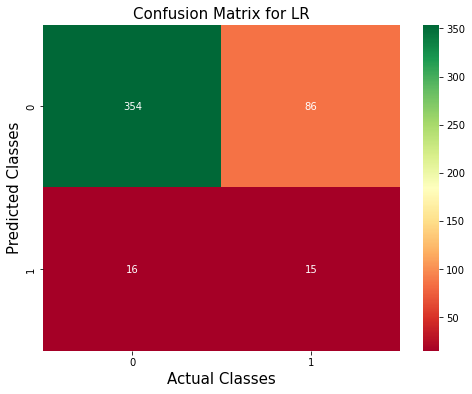

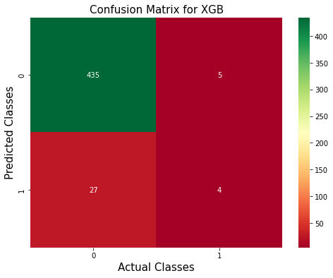

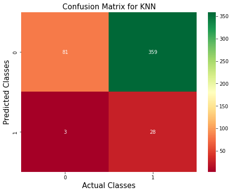

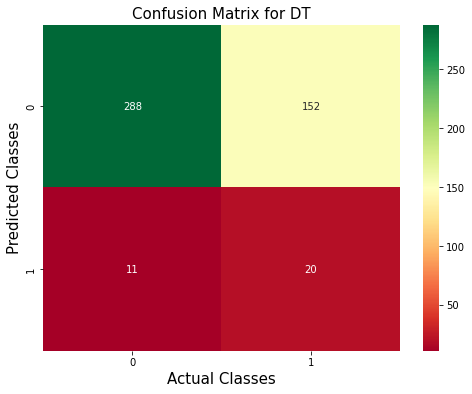

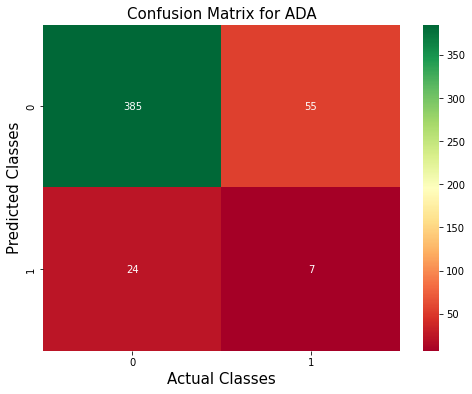

```python
xgb = XGBClassifier()
logreg= LogisticRegression()
knn = KNeighborsClassifier()
svcl = SVC()

adb = AdaBoostClassifier()

dtclf =DecisionTreeClassifier()
rfclf =RandomForestClassifier()



#prepare configuration for cross validation test harness
seed = 42

# prepare models

models = []
models.append(('LR', LogisticRegression()))
models.append(('XGB', XGBClassifier(random_state=1, eval_metric='mlogloss')))
models.append(('KNN', KNeighborsClassifier(5)))
models.append(('DT', DecisionTreeClassifier(max_depth=5)))
models.append(('RF', RandomForestClassifier(n_estimators=196)))
models.append(('ADA', AdaBoostClassifier()))
models.append(('SVC', SVC()))
xgb = XGBClassifier()
logreg= LogisticRegression()
knn = KNeighborsClassifier()
svcl = SVC()

adb = AdaBoostClassifier()

dtclf =DecisionTreeClassifier()
rfclf =RandomForestClassifier()


#prepare configuration for cross validation test harness
seed = 42

# prepare models

models = []
models.append(('LR', LogisticRegression()))
models.append(('XGB', XGBClassifier(random_state=1, eval_metric='mlogloss')))
models.append(('KNN', KNeighborsClassifier(5)))
models.append(('DT', DecisionTreeClassifier(max_depth=5)))
models.append(('RF', RandomForestClassifier(n_estimators=196)))
models.append(('ADA', AdaBoostClassifier()))
models.append(('SVC', SVC()))


#evaluate each model in turn

results = []
names = []
scoring = 'accuracy'
precision=[]
recall=[]

for name, model in models:

    clf = model.fit(X_train, y_train)
    pred = clf.predict(X_test)

    cv_results=accuracy_score(y_test, pred)


    tn, fp, fn, tp = confusion_matrix(y_test,pred).ravel()
        #visualization of confusion matrix in the form of a heatmap

    cm= confusion_matrix(y_test, pred)
    plt.figure(figsize = (8, 6))
    sns.heatmap(cm, annot = True, cmap = 'RdYlGn', fmt = 'd')
    plt.xlabel('Actual Classes', fontsize = 15)
    plt.ylabel('Predicted Classes', fontsize = 15)
    plt.title('Confusion Matrix for '+ str(name), fontsize = 15);
    plt.show
    print(name)
    print(classification_report(y_test, pred))

    recallv = round(tp/(tp+fn), 3)
    precisionv = round(tp/(tp+fp), 3)
    recall.append(recallv)
    precision.append(precisionv)

    results.append(cv_results)
    names.append(name)
    msg = "%s: %f %f %f" % (name, cv_results.mean(), precisionv,recallv)
   # print(msg)
```

```python
result_sm_pca = pd.DataFrame({'Model' :
                           names,
                       'Accuracy' : results,
                      'Recall' : recall,
                      'Precision' : precision,
                      })
result_sm_pca
```

|  | Model | Accuracy | Recall | Precision |
| --- | --- | --- | --- | --- |
| 0 | LR | 0.783439 | 0.484 | 0.149 |
| 1 | XGB | 0.932059 | 0.129 | 0.444 |
| 2 | KNN | 0.231423 | 0.903 | 0.072 |
| 3 | DT | 0.653928 | 0.645 | 0.116 |
| 4 | RF | 0.934183 | 0.000 | NaN |
| 5 | ADA | 0.832272 | 0.226 | 0.113 |
| 6 | SVC | 0.934183 | 0.000 | NaN |